# Analysis_ReadingSpeed

### Visualise outcome variable and predictors

The reading_speed_measure_data has 1936 observations.

We create graphs to inspect speed of reading and its connection to other variables. Graphs on the distribution of ReadingRate and connection to UserId, StoryId, DaysUntilDeadline, and WindowWidth were created before the reader characteristics model, and so they are not repeated here.

### Connection to previous event

We visualise connection to previous events to see if reading speed on the previous page, or on the page before the previous, is connected to reading speed on the current page-view.

Previous page-view:

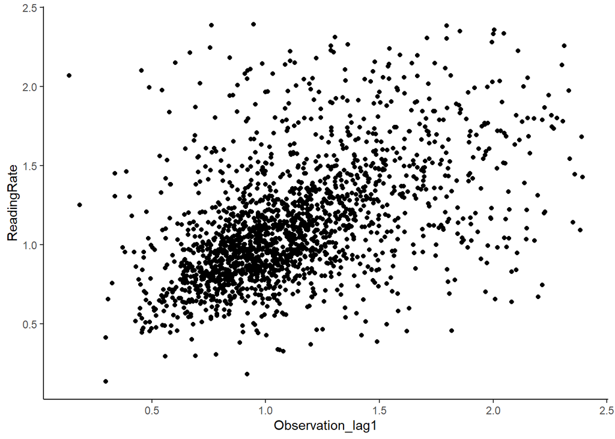

```r
ggplot(
    reading_speed_measure_data,
    aes(x = Observation_lag1, y = ReadingRate)
) +
    geom_point() +
    theme_classic()
```

Two pages before the current page-view:

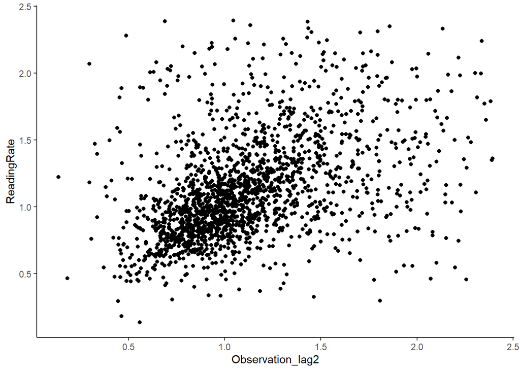

```r
ggplot(
    reading_speed_measure_data,
    aes(x = Observation_lag2, y = ReadingRate)
) +
    geom_point() +
    theme_classic()
```

### Reading session

Reading session number:

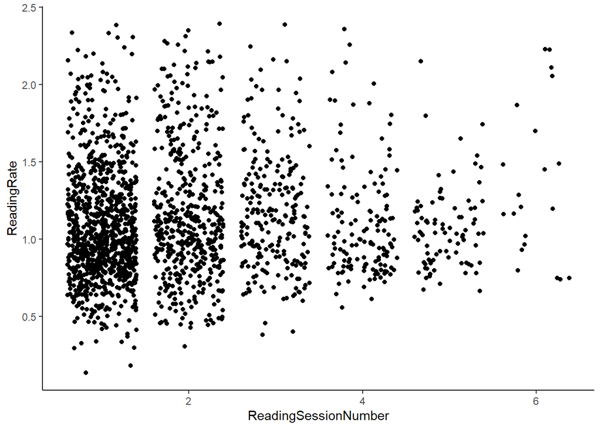

```r
ggplot(
    reading_speed_measure_data,
    aes(x = ReadingSessionNumber, y = ReadingRate)
) +
    geom_jitter() +
    theme_classic()
```

Time in a reading session:

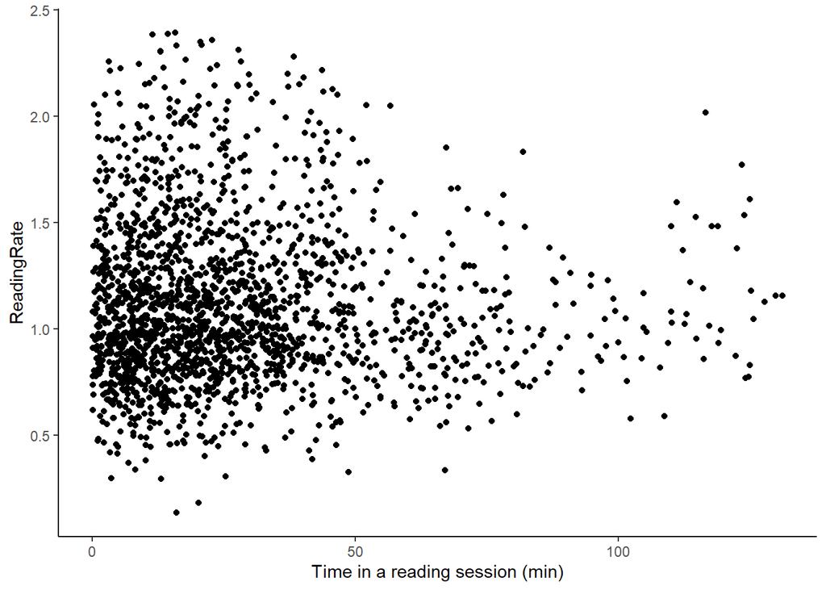

```r
ggplot(
    reading_speed_measure_data,
    aes(x = FirstCumulativeRSTime, y = ReadingRate)
) +
    geom_point() +
    theme_classic() +
    labs(x = "Time in a reading session (min)")
```

### Location in text

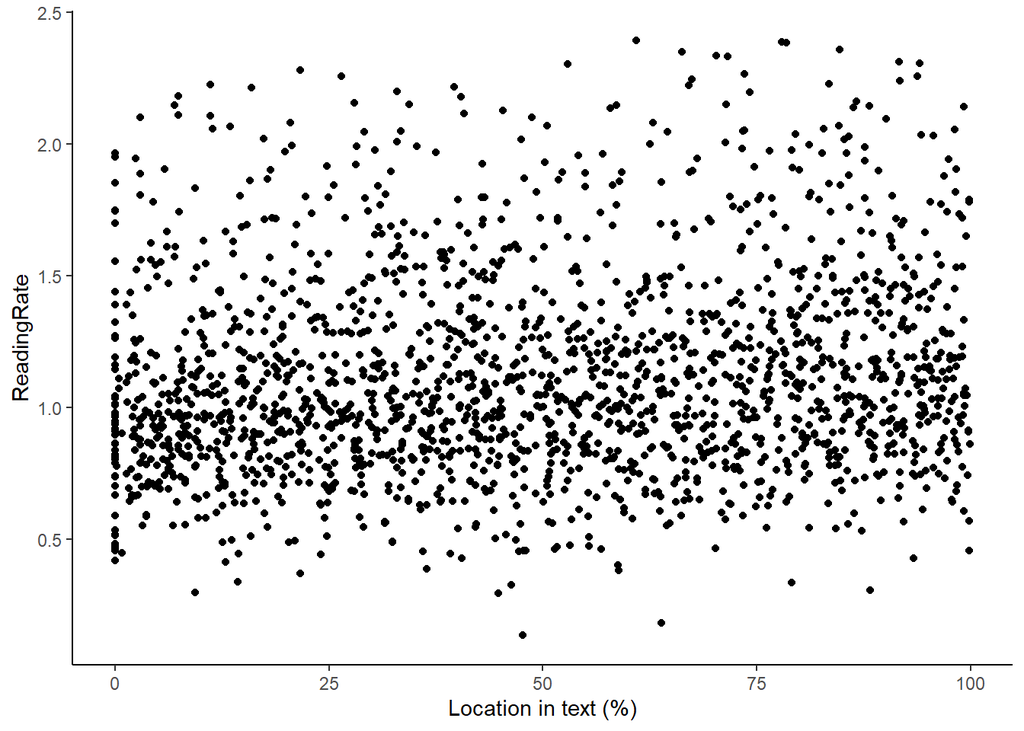

```r
ggplot(
    reading_speed_measure_data,
    aes(x = PercentageLocation * 100, y = ReadingRate)
) +
    geom_point() +
    theme_classic() +
    labs(x = "Location in text (%)")
```

Reading speed may increase towards the end of the text.

### Set contrasts to predictors

Predictors in the model are given contrasts. Continuous variables are scaled and centered, whereas categorical variables are given helmert contrasts. Helmert contrasts are used to control for uneven levels in categorical variables.

```r
# Event k-1
reading_speed_measure_data$Observation_lag1.sc <-
    scale(reading_speed_measure_data$Observation_lag1,
        center = TRUE,
        scale = TRUE
    )
# Event k-2
reading_speed_measure_data$Observation_lag2.sc <-
    scale(reading_speed_measure_data$Observation_lag2,
        center = TRUE,
        scale = TRUE
    )
# Window width (control variable)
reading_speed_measure_data$WindowWidth.sc <-
    scale(reading_speed_measure_data$WindowWidth,
        center = TRUE,
        scale = TRUE
    )
# Days until reading deadline (control variable)
reading_speed_measure_data$DaysUntilDeadline.sc <-
    scale(reading_speed_measure_data$FirstTimeUntilDeadlineDays,
        center = TRUE,
        scale = TRUE
    )
# Reading session number
reading_speed_measure_data$ReadingSessionNumber.sc <-
    scale(reading_speed_measure_data$ReadingSessionNumber,
        center = TRUE,
        scale = TRUE
    )
# Time in a reading session
reading_speed_measure_data$TimeInReadingSession.sc <-
    scale(reading_speed_measure_data$FirstCumulativeRSTime,
        center = TRUE,
        scale = TRUE
    )
# Location in text
reading_speed_measure_data$PercentageLocation.sc <-
    scale(reading_speed_measure_data$PercentageLocation,
        center = TRUE,
        scale = TRUE
    )
```

### Modelling by Event Properties

#### Additive model

First, we build the additive intercepts-only model structure.

```r
AdditiveStructure_EP_nested_interceptsonly <- (
    "ReadingRate ~ WindowWidth.sc + DaysUntilDeadline.sc + Observation_lag1.sc + Observation_lag2.sc + ReadingSessionNumber.sc + TimeInReadingSession.sc + PercentageLocation.sc + (1 | StoryId / UserId)"
)
```

Fit the additive, random-intercepts only model:

```r
Speed_EP_AdditiveModel_nested_interceptsonly <- lmer(
    AdditiveStructure_EP_nested_interceptsonly,
    data = reading_speed_measure_data,
    control = lmerControl(optimizer = "bobyqa")
)
```

Check number of parameters against the number of observations in the additive, intercepts-only model:

```r
fepar_EP <- lme4::getME(Speed_EP_AdditiveModel_nested_interceptsonly, name = "p") # number of fixed effect parameters
repar_EP <- lme4::getME(Speed_EP_AdditiveModel_nested_interceptsonly, name = "m") # number of random effect parameters inc covariances
par_EP <- fepar_EP + repar_EP
n_EP <- lme4::getME(Speed_EP_AdditiveModel_nested_interceptsonly, name = "n")
# top limits of analysis
## avoid overfitting with n/k >= 15
n_EP/par_EP >= 15
```

```
## [1] TRUE
```

```r
## limit computational requirements with 100 000 > 10*par^2
100000 > 10*par_EP^2
```

```
## [1] TRUE
```

The model includes 10 parameters before adding interactions, and 1816 observations. Previous research has suggested that each parameter in a model has at least 15 observations. Our sample exceeds this threshold considering that 1816/10 = 181.6

We then add random slopes in the additive model by the ‘best-path’ algorithm described by @barrRandomEffectsStructure2013a. With this method, we test addition of each fixed effect variable as a random slope using a liberal alpha-level (a = .20) against the intercepts-only model. If multiple variables contribute to the model with p < .20, we accept the variable with lowest p-value as slope, and resume testing by adding each fixed effect variable at a time as a random slope and compare to model with the previously accepted slope. This method allows us to explore meaningful random slopes with a data-driven approach.

```r
# slope test 1
    ## 1.1 WW
    ## 1.2 DUD
    ## 1.3 Event k-1
    ## 1.4 Event k-2
    ## 1.5 RSN
    ## 1.6 TRS
    ## 1.7 Loc
###################
# 1
AdditiveStructure_EP_nested_slope1_1 <- (
    "ReadingRate ~ WindowWidth.sc + DaysUntilDeadline.sc + Observation_lag1.sc + Observation_lag2.sc + ReadingSessionNumber.sc + TimeInReadingSession.sc + PercentageLocation.sc + (1 + WindowWidth.sc | StoryId / UserId)"
)
Speed_EP_AdditiveModel_nested1_1 <- lmer( # sing
    AdditiveStructure_EP_nested_slope1_1,
    data = reading_speed_measure_data,
    control = lmerControl(optimizer = "bobyqa"),
    REML = FALSE
)
anova(Speed_EP_AdditiveModel_nested_interceptsonly, Speed_EP_AdditiveModel_nested1_1) # WW does not contribute, p > .2
# 2
AdditiveStructure_EP_nested_slope1_2 <- (
    "ReadingRate ~ WindowWidth.sc + DaysUntilDeadline.sc + Observation_lag1.sc + Observation_lag2.sc + ReadingSessionNumber.sc + TimeInReadingSession.sc + PercentageLocation.sc + (1 + DaysUntilDeadline.sc | StoryId / UserId)"
)
Speed_EP_AdditiveModel_nested1_2 <- lmer(
    AdditiveStructure_EP_nested_slope1_2,
    data = reading_speed_measure_data,
    control = lmerControl(optimizer = "bobyqa"),
    REML = FALSE
)
anova(Speed_EP_AdditiveModel_nested1_2, Speed_EP_AdditiveModel_nested_interceptsonly) # DUD sig contributes, p = .0017
# 3
AdditiveStructure_EP_nested_slope1_3 <- (
    "ReadingRate ~ WindowWidth.sc + DaysUntilDeadline.sc + Observation_lag1.sc + Observation_lag2.sc + ReadingSessionNumber.sc + TimeInReadingSession.sc + PercentageLocation.sc + (1 + Observation_lag1.sc | StoryId / UserId)"
)
Speed_EP_AdditiveModel_nested1_3 <- lmer( # sing
    AdditiveStructure_EP_nested_slope1_3,
    data = reading_speed_measure_data,
    control = lmerControl(optimizer = "bobyqa"),
    REML = FALSE
)
anova(Speed_EP_AdditiveModel_nested1_3, Speed_EP_AdditiveModel_nested_interceptsonly) # sig contributes, p = .041
# 4
AdditiveStructure_EP_nested_slope1_4 <- (
    "ReadingRate ~ WindowWidth.sc + DaysUntilDeadline.sc + Observation_lag1.sc + Observation_lag2.sc + ReadingSessionNumber.sc + TimeInReadingSession.sc + PercentageLocation.sc + (1 + Observation_lag2.sc | StoryId / UserId)"
)
Speed_EP_AdditiveModel_nested1_4 <- lmer( # sing
    AdditiveStructure_EP_nested_slope1_4,
    data = reading_speed_measure_data,
    control = lmerControl(optimizer = "bobyqa"),
    REML = FALSE
)
anova(Speed_EP_AdditiveModel_nested1_4, Speed_EP_AdditiveModel_nested_interceptsonly) # contributes, p = .187
# 5
AdditiveStructure_EP_nested_slope1_5 <- (
    "ReadingRate ~ WindowWidth.sc + DaysUntilDeadline.sc + Observation_lag1.sc + Observation_lag2.sc + ReadingSessionNumber.sc + TimeInReadingSession.sc + PercentageLocation.sc + (1 + ReadingSessionNumber.sc | StoryId / UserId)"
)
Speed_EP_AdditiveModel_nested1_5 <- lmer(
    AdditiveStructure_EP_nested_slope1_5,
    data = reading_speed_measure_data,
    control = lmerControl(optimizer = "bobyqa"),
    REML = FALSE
)
anova(Speed_EP_AdditiveModel_nested1_5, Speed_EP_AdditiveModel_nested_interceptsonly) # sig contributes, p = .0032
# 6
AdditiveStructure_EP_nested_slope1_6 <- (
    "ReadingRate ~ WindowWidth.sc + DaysUntilDeadline.sc + Observation_lag1.sc + Observation_lag2.sc + ReadingSessionNumber.sc + TimeInReadingSession.sc + PercentageLocation.sc + (1 + TimeInReadingSession.sc | StoryId / UserId)"
)
Speed_EP_AdditiveModel_nested1_6 <- lmer(
    AdditiveStructure_EP_nested_slope1_6,
    data = reading_speed_measure_data,
    control = lmerControl(optimizer = "bobyqa"),
    REML = FALSE
)
anova(Speed_EP_AdditiveModel_nested1_6, Speed_EP_AdditiveModel_nested_interceptsonly) # does not contribute, p > .2
# 7
AdditiveStructure_EP_nested_slope1_7 <- (
    "ReadingRate ~ WindowWidth.sc + DaysUntilDeadline.sc + Observation_lag1.sc + Observation_lag2.sc + ReadingSessionNumber.sc + TimeInReadingSession.sc + PercentageLocation.sc + (1 + PercentageLocation.sc | StoryId / UserId)"
)
Speed_EP_AdditiveModel_nested1_7 <- lmer(
    AdditiveStructure_EP_nested_slope1_7,
    data = reading_speed_measure_data,
    control = lmerControl(optimizer = "bobyqa"),
    REML = FALSE
)
anova(Speed_EP_AdditiveModel_nested1_7, Speed_EP_AdditiveModel_nested_interceptsonly) # sig contributes, p = .0012
```

Location in text contributes the most to the model, and so it is added as the first random slope.

```r
# slope test 2
## Start adding all slopes again to the most sig slope: Loc
    ## 2.1: WW
    ## 2.2: DUD
    ## 2.3: Event k-1
    ## 2.4: Event k-2
    ## 2.5: RSN
    ## 2.6: TRS
###################
AdditiveStructure_EP_nested_slope2 <- (
    "ReadingRate ~ WindowWidth.sc + DaysUntilDeadline.sc + Observation_lag1.sc + Observation_lag2.sc + ReadingSessionNumber.sc + TimeInReadingSession.sc + PercentageLocation.sc + (1 + PercentageLocation.sc | StoryId / UserId)"
)
Speed_EP_AdditiveModel_nested2 <- lmer(
    AdditiveStructure_EP_nested_slope2,
    data = reading_speed_measure_data,
    control = lmerControl(optimizer = "bobyqa"),
    REML = FALSE
)
## 2_1
AdditiveStructure_EP_nested_slope2_1 <- (
    "ReadingRate ~ WindowWidth.sc + DaysUntilDeadline.sc + Observation_lag1.sc + Observation_lag2.sc + ReadingSessionNumber.sc + TimeInReadingSession.sc + PercentageLocation.sc + (1 + PercentageLocation.sc + WindowWidth.sc | StoryId / UserId)"
)
Speed_EP_AdditiveModel_nested2_1 <- lmer( # sing
    AdditiveStructure_EP_nested_slope2_1,
    data = reading_speed_measure_data,
    control = lmerControl(optimizer = "bobyqa"),
    REML = FALSE
)
anova(Speed_EP_AdditiveModel_nested2, Speed_EP_AdditiveModel_nested2_1) # does not contribute, p > .2
## 2_2
AdditiveStructure_EP_nested_slope2_2 <- (
    "ReadingRate ~ WindowWidth.sc + DaysUntilDeadline.sc + Observation_lag1.sc + Observation_lag2.sc + ReadingSessionNumber.sc + TimeInReadingSession.sc + PercentageLocation.sc + (1 + PercentageLocation.sc + DaysUntilDeadline.sc | StoryId / UserId)"
)
Speed_EP_AdditiveModel_nested2_2 <- lmer( # sing
    AdditiveStructure_EP_nested_slope2_2,
    data = reading_speed_measure_data,
    control = lmerControl(optimizer = "bobyqa"),
    REML = FALSE
)
anova(Speed_EP_AdditiveModel_nested2, Speed_EP_AdditiveModel_nested2_2) # sig contributes, p = .031
## 2_3
AdditiveStructure_EP_nested_slope2_3 <- (
    "ReadingRate ~ WindowWidth.sc + DaysUntilDeadline.sc + Observation_lag1.sc + Observation_lag2.sc + ReadingSessionNumber.sc + TimeInReadingSession.sc + PercentageLocation.sc + (1 + PercentageLocation.sc + Observation_lag1.sc | StoryId / UserId)"
)
Speed_EP_AdditiveModel_nested2_3 <- lmer( # sing
    AdditiveStructure_EP_nested_slope2_3,
    data = reading_speed_measure_data,
    control = lmerControl(optimizer = "bobyqa"),
    REML = FALSE
)
anova(Speed_EP_AdditiveModel_nested2, Speed_EP_AdditiveModel_nested2_3) # contributes, p = .064
## 2_4
AdditiveStructure_EP_nested_slope2_4 <- (
    "ReadingRate ~ WindowWidth.sc + DaysUntilDeadline.sc + Observation_lag1.sc + Observation_lag2.sc + ReadingSessionNumber.sc + TimeInReadingSession.sc + PercentageLocation.sc + (1 + PercentageLocation.sc + Observation_lag2.sc | StoryId / UserId)"
)
Speed_EP_AdditiveModel_nested2_4 <- lmer( # sing
    AdditiveStructure_EP_nested_slope2_4,
    data = reading_speed_measure_data,
    control = lmerControl(optimizer = "bobyqa"),
    REML = FALSE
)
anova(Speed_EP_AdditiveModel_nested2, Speed_EP_AdditiveModel_nested2_4) # does not contribute, p > .2
## 2_5
AdditiveStructure_EP_nested_slope2_5 <- (
    "ReadingRate ~ WindowWidth.sc + DaysUntilDeadline.sc + Observation_lag1.sc + Observation_lag2.sc + ReadingSessionNumber.sc + TimeInReadingSession.sc + PercentageLocation.sc + (1 + PercentageLocation.sc + ReadingSessionNumber.sc | StoryId / UserId)"
)
Speed_EP_AdditiveModel_nested2_5 <- lmer( # sing
    AdditiveStructure_EP_nested_slope2_5,
    data = reading_speed_measure_data,
    control = lmerControl(optimizer = "bobyqa"),
    REML = FALSE
)
anova(Speed_EP_AdditiveModel_nested2, Speed_EP_AdditiveModel_nested2_5) # does not contribute, p > .2
## 2_6
AdditiveStructure_EP_nested_slope2_6 <- (
    "ReadingRate ~ WindowWidth.sc + DaysUntilDeadline.sc + Observation_lag1.sc + Observation_lag2.sc + ReadingSessionNumber.sc + TimeInReadingSession.sc + PercentageLocation.sc + (1 + PercentageLocation.sc + TimeInReadingSession.sc | StoryId / UserId)"
)
Speed_EP_AdditiveModel_nested2_6 <- lmer( # sing
    AdditiveStructure_EP_nested_slope2_6,
    data = reading_speed_measure_data,
    control = lmerControl(optimizer = "bobyqa"),
    REML = FALSE
)
anova(Speed_EP_AdditiveModel_nested2, Speed_EP_AdditiveModel_nested2_6) # contributes, p = .125
```

Days until deadline contributes the most to the model in slope test round 2. It is added in the model in addition to location in text.

```r
# slope test 3
## Start adding all slopes again to the most sig slopes: LOC + DUD
    ## 3_1: WW
    ## 3_2: Event k-1
    ## 3_3: Event k-2
    ## 3_4: RSN
    ## 3_5: TRS
###################
AdditiveStructure_EP_nested_slope3 <- (
    "ReadingRate ~ WindowWidth.sc + DaysUntilDeadline.sc + Observation_lag1.sc + Observation_lag2.sc + ReadingSessionNumber.sc + TimeInReadingSession.sc + PercentageLocation.sc + (1 + PercentageLocation.sc + DaysUntilDeadline.sc | StoryId / UserId)"
)
Speed_EP_AdditiveModel_nested3 <- lmer( # sing
    AdditiveStructure_EP_nested_slope3,
    data = reading_speed_measure_data,
    control = lmerControl(optimizer = "bobyqa"),
    REML = FALSE
)
## 3_1
AdditiveStructure_EP_nested_slope3_1 <- (
    "ReadingRate ~ WindowWidth.sc + DaysUntilDeadline.sc + Observation_lag1.sc + Observation_lag2.sc + ReadingSessionNumber.sc + TimeInReadingSession.sc + PercentageLocation.sc + (1 + PercentageLocation.sc + DaysUntilDeadline.sc + WindowWidth.sc | StoryId / UserId)"
)
Speed_EP_AdditiveModel_nested3_1 <- lmer( # sing, nc
    AdditiveStructure_EP_nested_slope3_1,
    data = reading_speed_measure_data,
    control = lmerControl(optimizer = "bobyqa"),
    REML = FALSE
)
anova(Speed_EP_AdditiveModel_nested3, Speed_EP_AdditiveModel_nested3_1) # does not contribute, p > .2
## 3_2
AdditiveStructure_EP_nested_slope3_2 <- (
    "ReadingRate ~ WindowWidth.sc + DaysUntilDeadline.sc + Observation_lag1.sc + Observation_lag2.sc + ReadingSessionNumber.sc + TimeInReadingSession.sc + PercentageLocation.sc + (1 + PercentageLocation.sc + DaysUntilDeadline.sc + Observation_lag1.sc | StoryId / UserId)"
)
Speed_EP_AdditiveModel_nested3_2 <- lmer( # sing, nc
    AdditiveStructure_EP_nested_slope3_2,
    data = reading_speed_measure_data,
    control = lmerControl(optimizer = "bobyqa"),
    REML = FALSE
)
anova(Speed_EP_AdditiveModel_nested3, Speed_EP_AdditiveModel_nested3_2) # does not contribute, p > .2
## 3_3
AdditiveStructure_EP_nested_slope3_3 <- (
    "ReadingRate ~ WindowWidth.sc + DaysUntilDeadline.sc + Observation_lag1.sc + Observation_lag2.sc + ReadingSessionNumber.sc + TimeInReadingSession.sc + PercentageLocation.sc + (1 + PercentageLocation.sc + DaysUntilDeadline.sc + Observation_lag2.sc | StoryId / UserId)"
)
Speed_EP_AdditiveModel_nested3_3 <- lmer( # sing, nc
    AdditiveStructure_EP_nested_slope3_3,
    data = reading_speed_measure_data,
    control = lmerControl(optimizer = "bobyqa"),
    REML = FALSE
)
anova(Speed_EP_AdditiveModel_nested3, Speed_EP_AdditiveModel_nested3_3) # does not contribute, p > .2
## 3_4
AdditiveStructure_EP_nested_slope3_4 <- (
    "ReadingRate ~ WindowWidth.sc + DaysUntilDeadline.sc + Observation_lag1.sc + Observation_lag2.sc + ReadingSessionNumber.sc + TimeInReadingSession.sc + PercentageLocation.sc + (1 + PercentageLocation.sc + DaysUntilDeadline.sc + ReadingSessionNumber.sc | StoryId / UserId)"
)
Speed_EP_AdditiveModel_nested3_4 <- lmer( # sing
    AdditiveStructure_EP_nested_slope3_4,
    data = reading_speed_measure_data,
    control = lmerControl(optimizer = "bobyqa"),
    REML = FALSE
)
anova(Speed_EP_AdditiveModel_nested3, Speed_EP_AdditiveModel_nested3_4) # does not contribute, p > .2
## 3_5
AdditiveStructure_EP_nested_slope3_5 <- (
    "ReadingRate ~ WindowWidth.sc + DaysUntilDeadline.sc + Observation_lag1.sc + Observation_lag2.sc + ReadingSessionNumber.sc + TimeInReadingSession.sc + PercentageLocation.sc + (1 + PercentageLocation.sc + DaysUntilDeadline.sc + TimeInReadingSession.sc | StoryId / UserId)"
)
Speed_EP_AdditiveModel_nested3_5 <- lmer( # sing
    AdditiveStructure_EP_nested_slope3_5,
    data = reading_speed_measure_data,
    control = lmerControl(optimizer = "bobyqa"),
    REML = FALSE
)
anova(Speed_EP_AdditiveModel_nested3, Speed_EP_AdditiveModel_nested3_5) # does not contribute, p > .2
```

None of the remaining slopes significantly add to the model, and so our final additive model includes random slopes for location in text, and days until reading deadline. Refit the additive model with REML:

```r
AdditiveStructure_EP_nested_slope3 <- (
    "ReadingRate ~ WindowWidth.sc + DaysUntilDeadline.sc + Observation_lag1.sc + Observation_lag2.sc + ReadingSessionNumber.sc + TimeInReadingSession.sc + PercentageLocation.sc + (1 + PercentageLocation.sc + DaysUntilDeadline.sc | StoryId / UserId)"
)
Speed_EP_AdditiveModel_nested_slopes <- lmer(
    AdditiveStructure_EP_nested_slope3,
    data = reading_speed_measure_data,
    control = lmerControl(optimizer = "bobyqa"),
    REML = TRUE
)
```

```
## boundary (singular) fit: see help('isSingular')
```

The additive model with random slopes is singular. To address this, we simplify the model backward stepwise. Selection is done according to the following priority:

```
1. Remove slopes that account for the lowest amount of variance
2. Remove fixed effects that contribute the least to the model, according to p-values
```

Selection is done manually, removing a single variable at a time. Selection is only done until the additive model converges and is no longer singular.

```r
# backward-selection of slopes
## 1: remove the slope that accounts for the least variance, until convergence
##########
# see which slope accounts for the lowest amount of variance
summary(Speed_EP_AdditiveModel_nested_slopes) # Location accounts for the least variance
# Remove Location slope
AdditiveStructure_EP_nested_slope5_1 <- (
    "ReadingRate ~ WindowWidth.sc + DaysUntilDeadline.sc + Observation_lag1.sc + Observation_lag2.sc + ReadingSessionNumber.sc + TimeInReadingSession.sc + PercentageLocation.sc + (1 + DaysUntilDeadline.sc | StoryId / UserId)"
)
AdditiveStructure_EP_nested_slope5_1 <- lmer(
    AdditiveStructure_EP_nested_slope5_1,
    data = reading_speed_measure_data,
    control = lmerControl(optimizer = "bobyqa")
)
```

The additive model converges after removal of the random slope of location in text. The final additive model includes a random slope of days until reading deadline only.

Inspect model values:

```r
AdditiveStructure_EP_nested_slope5_1 <- (
    "ReadingRate ~ WindowWidth.sc + DaysUntilDeadline.sc + Observation_lag1.sc + Observation_lag2.sc + ReadingSessionNumber.sc + TimeInReadingSession.sc + PercentageLocation.sc + (1 + DaysUntilDeadline.sc | StoryId / UserId)"
)
AdditiveStructure_EP_nested_slope5_1 <- lmer(
    AdditiveStructure_EP_nested_slope5_1,
    data = reading_speed_measure_data,
    control = lmerControl(optimizer = "bobyqa")
)
summary(AdditiveStructure_EP_nested_slope5_1)
```

```
## Linear mixed model fit by REML. t-tests use Satterthwaite's method [
## lmerModLmerTest]
## Formula: AdditiveStructure_EP_nested_slope5_1
##    Data: reading_speed_measure_data
## Control: lmerControl(optimizer = "bobyqa")
##
## REML criterion at convergence: 961.6
##
## Scaled residuals:
##     Min      1Q  Median      3Q     Max
## -4.0614 -0.5527 -0.0886  0.4185  4.5663
##
## Random effects:
##  Groups         Name                 Variance Std.Dev. Corr
##  UserId:StoryId (Intercept)          0.022993 0.15164
##                 DaysUntilDeadline.sc 0.003204 0.05660  0.87
##  StoryId        (Intercept)          0.003025 0.05500
##                 DaysUntilDeadline.sc 0.004623 0.06799  0.17
##  Residual                            0.089752 0.29959
## Number of obs: 1816, groups:  UserId:StoryId, 60; StoryId, 9
##
## Fixed effects:
##                           Estimate Std. Error         df t value Pr(>|t|)
## (Intercept)              1.105e+00  3.051e-02  6.758e+00  36.228 5.39e-09 ***
## WindowWidth.sc          -1.679e-02  2.236e-02  5.584e+01  -0.751   0.4559
## DaysUntilDeadline.sc     4.290e-02  3.080e-02  6.080e+00   1.393   0.2125
## Observation_lag1.sc      6.548e-02  9.019e-03  1.800e+03   7.260 5.73e-13 ***
## Observation_lag2.sc      1.982e-02  8.942e-03  1.802e+03   2.217   0.0268 *
## ReadingSessionNumber.sc  1.429e-02  1.865e-02  1.193e+02   0.766   0.4451
## TimeInReadingSession.sc -1.632e-02  1.373e-02  4.032e+02  -1.188   0.2355
## PercentageLocation.sc    5.100e-02  1.078e-02  4.411e+02   4.730 3.03e-06 ***
## ---
## Signif. codes:  0 '***' 0.001 '**' 0.01 '*' 0.05 '.' 0.1 ' ' 1
##
## Correlation of Fixed Effects:
##             (Intr) WndwW. DysUD. Obs_1. Obs_2. RdnSN. TmIRS.
## WndwWdth.sc -0.258
## DysUntlDdl.  0.208 -0.009
## Obsrvtn_l1.  0.018  0.009 -0.032
## Obsrvtn_l2.  0.024  0.010 -0.030 -0.186
## RdngSssnNm. -0.010  0.105  0.306 -0.011  0.002
## TmInRdngSs.  0.007  0.031 -0.007  0.067  0.060  0.290
## PrcntgLctn. -0.015 -0.078  0.003 -0.142 -0.142 -0.358 -0.648
```

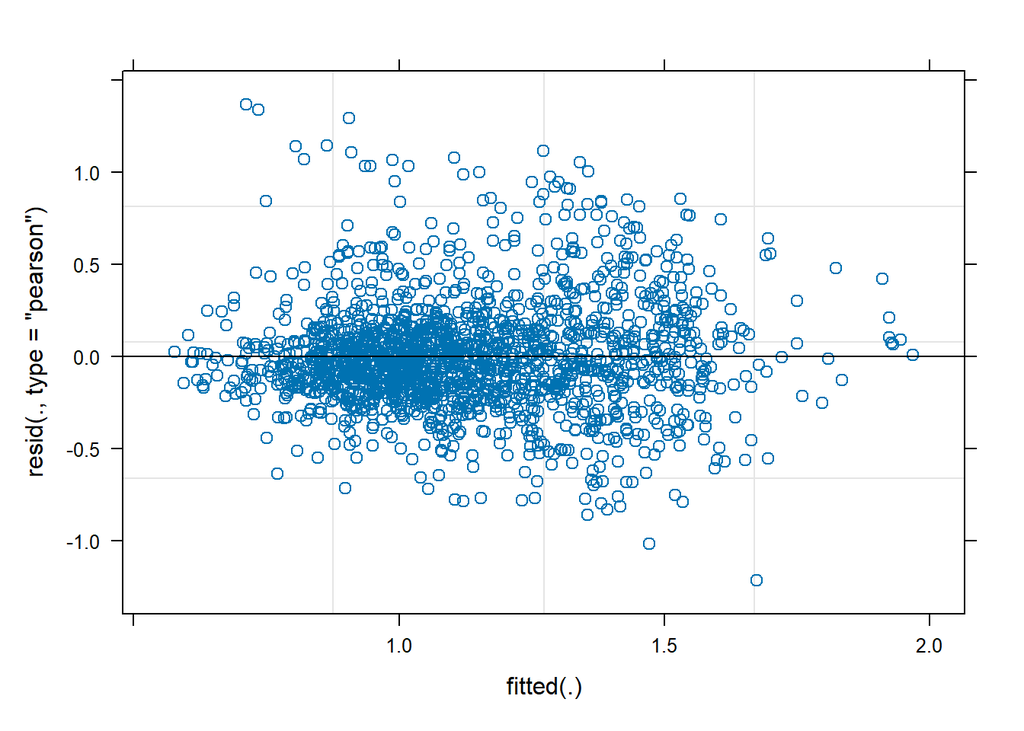

```r
plot(AdditiveStructure_EP_nested_slope5_1)
```

```r
fixef(AdditiveStructure_EP_nested_slope5_1)
```

```
##             (Intercept)          WindowWidth.sc    DaysUntilDeadline.sc
##              1.10535006             -0.01678716              0.04290004
##     Observation_lag1.sc     Observation_lag2.sc ReadingSessionNumber.sc
##              0.06548232              0.01982331              0.01428922
## TimeInReadingSession.sc   PercentageLocation.sc
##             -0.01631717              0.05100222
```

Check amount of parameters against the number of observations:

```r
fepar_EP_slopes <- lme4::getME(AdditiveStructure_EP_nested_slope5_1, name = "p") # number of fixed effect parameters
repar_EP_slopes <- lme4::getME(AdditiveStructure_EP_nested_slope5_1, name = "m") # number of random effect parameters inc covariances
par_EP_slopes <- fepar_EP_slopes + repar_EP_slopes
n_EP_slopes <- lme4::getME(AdditiveStructure_EP_nested_slope5_1, name = "n")
# top limits of analysis
## avoid overfitting with n/k >= 15
n_EP_slopes/par_EP_slopes >= 15
```

```
## [1] TRUE
```

```r
## limit computational requirements with 100 000 > 10*par^2
100000 > 10*par_EP_slopes^2
```

```
## [1] TRUE
```

We then add interactions to the additive model.

#### Interactive model

We create a new model structure with interactions between predictors of interest (all main effects apart from DaysUntilDeadline and WindowWidth which are used as control variables only). Only two-way interactions are included to avoid overfitting the model. No interactions are included between previous events (Observation_lag1 and Observation_lag2) and other predictors in the model (e.g. ReadingSessionNumber) to avoid multicollinearity.

```r
InteractiveStructure_EP_nested_slopes <- (
    "ReadingRate ~ WindowWidth.sc + DaysUntilDeadline.sc + Observation_lag1.sc + Observation_lag2.sc + ReadingSessionNumber.sc + TimeInReadingSession.sc + PercentageLocation.sc + Observation_lag1.sc : Observation_lag2.sc + ReadingSessionNumber.sc : TimeInReadingSession.sc + ReadingSessionNumber.sc : PercentageLocation.sc + TimeInReadingSession.sc : PercentageLocation.sc + (1 + DaysUntilDeadline.sc | StoryId / UserId)"
)
```

```r
Speed_EP_InteractiveModel_nested_slopes <- lmer(
    InteractiveStructure_EP_nested_slopes,
    data = reading_speed_measure_data,
    control = lmerControl(optimizer = "bobyqa"),
    REML = TRUE
)
```

The full interactive model structure converges.

Check number of parameters against the number of observations:

```r
fepar_EP_int <- lme4::getME(Speed_EP_InteractiveModel_nested_slopes, name = "p") # number of fixed effect parameters
repar_EP_int <- lme4::getME(Speed_EP_InteractiveModel_nested_slopes, name = "m") # number of random effect parameters inc covariances
par_EP_int <- fepar_EP_int + repar_EP_int
n_EP_int <- lme4::getME(Speed_EP_InteractiveModel_nested_slopes, name = "n")
# top limits of analysis
## avoid overfitting with n/k >= 15
n_EP_int/par_EP_int >= 15
```

```
## [1] TRUE
```

```r
## limit computational requirements with 100 000 > 10*par^2
100000 > 10*par_EP_int^2
```

```
## [1] TRUE
```

The interactive model includes 18 parameters (including the intercept, random effects, main effects, interactions, and random effect covariances). Previous research has suggested that each parameter in a model has at least 15 observations. Our sample exceeds this threshold considering that 1816/18 = 100.89.

Inspect model values:

```r
summary(Speed_EP_InteractiveModel_nested_slopes)
```

```
## Linear mixed model fit by REML. t-tests use Satterthwaite's method [
## lmerModLmerTest]
## Formula: InteractiveStructure_EP_nested_slopes
##    Data: reading_speed_measure_data
## Control: lmerControl(optimizer = "bobyqa")
##
## REML criterion at convergence: 981.3
##
## Scaled residuals:
##     Min      1Q  Median      3Q     Max
## -3.9483 -0.5410 -0.0865  0.4123  4.6874
##
## Random effects:
##  Groups         Name                 Variance Std.Dev. Corr
##  UserId:StoryId (Intercept)          0.022912 0.15137
##                 DaysUntilDeadline.sc 0.003022 0.05497  0.92
##  StoryId        (Intercept)          0.002717 0.05213
##                 DaysUntilDeadline.sc 0.005423 0.07364  0.10
##  Residual                            0.089425 0.29904
## Number of obs: 1816, groups:  UserId:StoryId, 60; StoryId, 9
##
## Fixed effects:
##                                                   Estimate Std. Error
## (Intercept)                                      1.120e+00  3.036e-02
## WindowWidth.sc                                  -1.476e-02  2.218e-02
## DaysUntilDeadline.sc                             4.684e-02  3.217e-02
## Observation_lag1.sc                              6.676e-02  9.094e-03
## Observation_lag2.sc                              2.275e-02  9.240e-03
## ReadingSessionNumber.sc                          2.496e-02  1.950e-02
## TimeInReadingSession.sc                         -1.359e-02  1.628e-02
## PercentageLocation.sc                            5.622e-02  1.180e-02
## Observation_lag1.sc:Observation_lag2.sc         -1.282e-02  6.784e-03
## ReadingSessionNumber.sc:TimeInReadingSession.sc  2.547e-02  1.387e-02
## ReadingSessionNumber.sc:PercentageLocation.sc   -1.650e-02  8.697e-03
## TimeInReadingSession.sc:PercentageLocation.sc   -1.091e-02  9.551e-03
##                                                         df t value Pr(>|t|)
## (Intercept)                                      7.135e+00  36.878 2.08e-09 ***
## WindowWidth.sc                                   5.035e+01  -0.666   0.5086
## DaysUntilDeadline.sc                             6.219e+00   1.456   0.1939
## Observation_lag1.sc                              1.789e+03   7.341 3.20e-13 ***
```

[output cut: 21 more lines]

```
## RdSN.:TIRS.  0.018  0.062  0.060 -0.028 -0.038  0.275 -0.209  0.327  0.007
## RdngSN.:PL. -0.023 -0.048 -0.038  0.046  0.064 -0.217  0.261 -0.286  0.014
## TmInRS.:PL. -0.126  0.059  0.045  0.014  0.017  0.133 -0.486  0.271 -0.004
##             RSN.:T RSN.:P
## WndwWdth.sc
## DysUntlDdl.
## Obsrvtn_l1.
## Obsrvtn_l2.
## RdngSssnNm.
## TmInRdngSs.
## PrcntgLctn.
## Obs_1.:O_2.
## RdSN.:TIRS.
## RdngSN.:PL. -0.479
## TmInRS.:PL.  0.254 -0.047
```

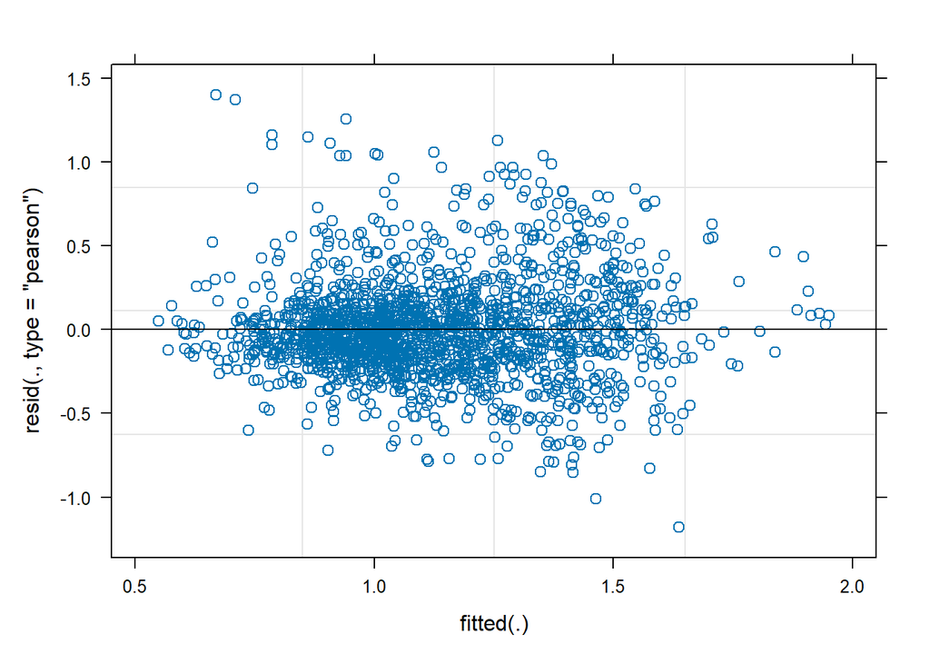

```r
plot(Speed_EP_InteractiveModel_nested_slopes)
```

```r
fixef(Speed_EP_InteractiveModel_nested_slopes)
```

```
##                                     (Intercept)
##                                      1.11976968
##                                  WindowWidth.sc
##                                     -0.01476341
##                            DaysUntilDeadline.sc
##                                      0.04683461
##                             Observation_lag1.sc
##                                      0.06676007
##                             Observation_lag2.sc
##                                      0.02274929
##                         ReadingSessionNumber.sc
##                                      0.02495957
##                         TimeInReadingSession.sc
##                                     -0.01359414
##                           PercentageLocation.sc
##                                      0.05622223
##         Observation_lag1.sc:Observation_lag2.sc
##                                     -0.01282236
## ReadingSessionNumber.sc:TimeInReadingSession.sc
##                                      0.02546507
##   ReadingSessionNumber.sc:PercentageLocation.sc
##                                     -0.01650013
##   TimeInReadingSession.sc:PercentageLocation.sc
##                                     -0.01090766
```

### Model Assumptions

All linear mixed models were tested for (1) multicollinearity, (2) influential observations, (3) heteroscedasticity, (4) normality of random effects, and (5) normality of residuals.

#### 1. Multicollinearity

We check for multicollinearity first with a correlation matrix:

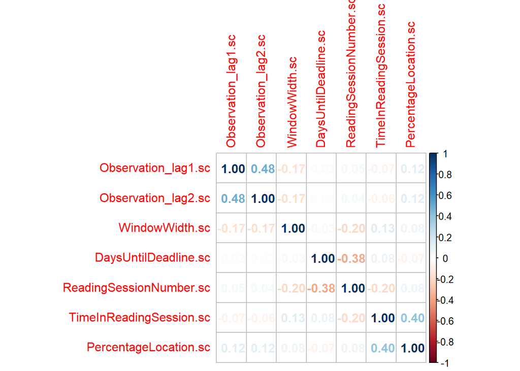

```r
corrplot(cor(remove_missing(reading_speed_measure_data[, c(
    "Observation_lag1.sc",
    "Observation_lag2.sc",
    "WindowWidth.sc",
    "DaysUntilDeadline.sc",
    "ReadingSessionNumber.sc",
    "TimeInReadingSession.sc",
    "PercentageLocation.sc"
    )])), method = "number")
```

None of the predictors show high correlations.

We then calculate Variance Inflation Factors (VIF):

```r
check_collinearity(Speed_EP_InteractiveModel_nested_slopes)
```

```
## # Check for Multicollinearity
##
## Low Correlation
##
##                                             Term  VIF   VIF 95% CI Increased SE
##                                   WindowWidth.sc 1.02 [1.00, 1.18]         1.01
##                             DaysUntilDeadline.sc 1.12 [1.08, 1.19]         1.06
##                              Observation_lag1.sc 1.10 [1.06, 1.17]         1.05
##                              Observation_lag2.sc 1.15 [1.10, 1.23]         1.07
##                          ReadingSessionNumber.sc 1.44 [1.36, 1.53]         1.20
##                          TimeInReadingSession.sc 2.46 [2.29, 2.65]         1.57
##                            PercentageLocation.sc 2.33 [2.17, 2.51]         1.53
##          Observation_lag1.sc:Observation_lag2.sc 1.11 [1.07, 1.18]         1.05
##  ReadingSessionNumber.sc:TimeInReadingSession.sc 1.57 [1.48, 1.68]         1.25
##    ReadingSessionNumber.sc:PercentageLocation.sc 1.46 [1.38, 1.56]         1.21
##    TimeInReadingSession.sc:PercentageLocation.sc 1.50 [1.41, 1.60]         1.22
##  Tolerance Tolerance 95% CI
##       0.98     [0.85, 1.00]
##       0.89     [0.84, 0.93]
##       0.91     [0.85, 0.95]
##       0.87     [0.82, 0.91]
##       0.70     [0.65, 0.74]
##       0.41     [0.38, 0.44]
##       0.43     [0.40, 0.46]
##       0.90     [0.84, 0.94]
##       0.64     [0.59, 0.67]
##       0.68     [0.64, 0.72]
##       0.67     [0.63, 0.71]
```

```
## Variable `Component` is not in your data frame :/
```

[figure not shown]

```r
plot(check_collinearity(Speed_EP_InteractiveModel_nested_slopes))
```

#### 2. Influential Observations

We test influential observations with Cook’s Distance:

```r
cooksd <-
     cooks.distance(Speed_EP_InteractiveModel_nested_slopes)
```

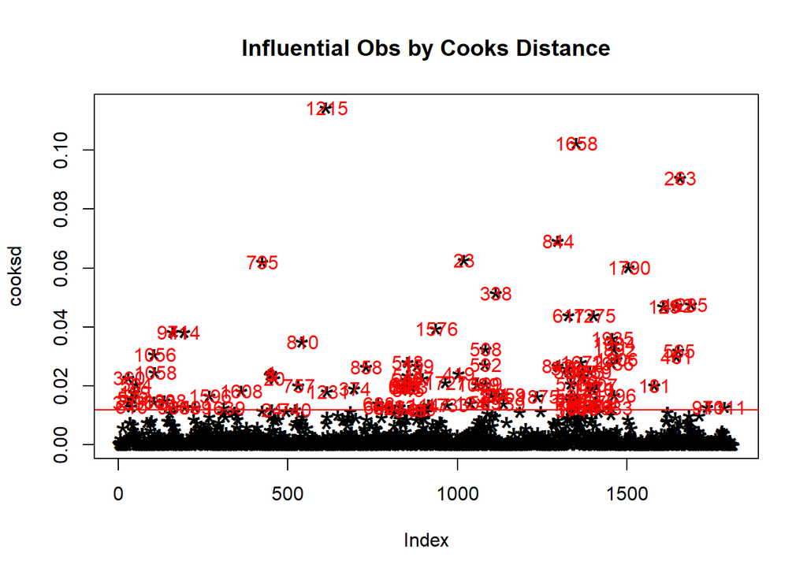

```r
plot(cooksd,
     pch = "*",
     cex = 2,
     main = "Influential Obs by Cooks Distance"
)
abline(h = 4 * mean(cooksd, na.rm = TRUE), col = "red")
text(
     x = 1:length(cooksd) + 1,
    y = cooksd,
    labels = ifelse(cooksd > 4 * mean(cooksd, na.rm = TRUE), names(cooksd), ""),
    col = "red"
)
```

The plot indicates that the dataset may include some influential observations. However, the cook’s distances are very conservative as the threshold is set at 0.0118966. Therefore, it is unlikely that these observations influence the model.

To further test influential observations we use performance::check_outliers:

```r
check_outliers(Speed_EP_InteractiveModel_nested_slopes)
```

```
## Some of the variables were in matrix-format - probably you used
##   `scale()` on your data?
##   If so, and you get an error, please try `datawizard::standardize()` to
##   standardize your data.
```

```
## OK: No outliers detected.
## - Based on the following method and threshold: cook (0.918).
## - For variable: (Whole model)
```

```
## Some of the variables were in matrix-format - probably you used
##   `scale()` on your data?
##   If so, and you get an error, please try `datawizard::standardize()` to
##   standardize your data.
```

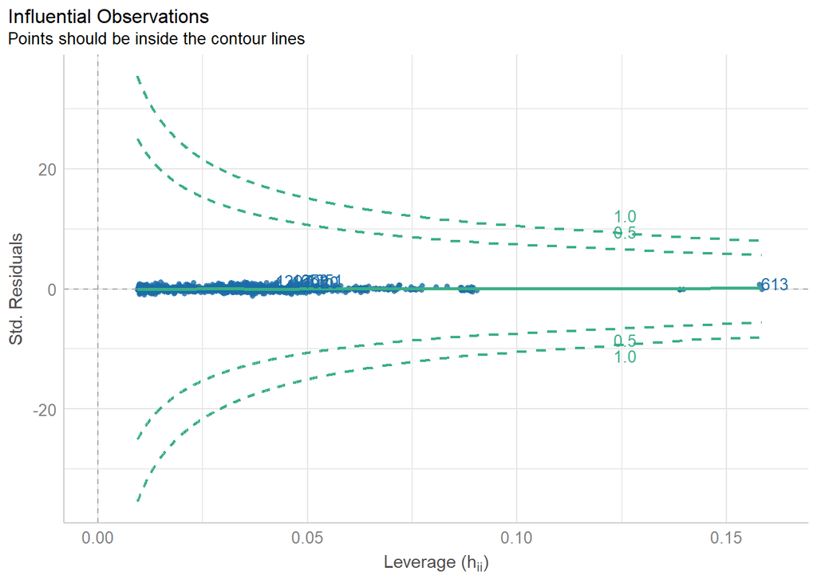

```r
plot(check_outliers(Speed_EP_InteractiveModel_nested_slopes))
```

Although Cook’s Distance indicates that the model has influential observations, the outlier test does not produce the same results. Considering the conservative Cook’s Distance limit, we assume that the model does not have influential outliers.

#### 3. Heteroscedasticity

We use the Breusch-Pagan test to check whether the variances of residuals in the model vary systematically:

```r
check_heteroscedasticity(Speed_EP_InteractiveModel_nested_slopes)
```

```
## OK: Error variance appears to be homoscedastic (p = 0.109).
```

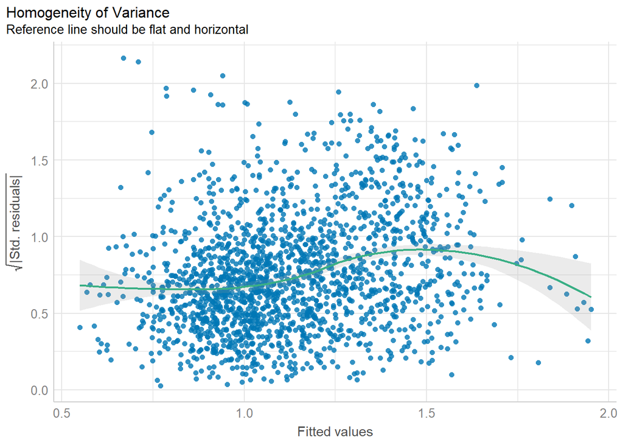

```r
plot(check_heteroscedasticity(Speed_EP_InteractiveModel_nested_slopes))
```

The test is not significant, indicating that the variances are homoscedastic in the model. The model aligns with the assumption of homoscedasticity.

#### 4. Normality of Random Effects

Random effects should be normally distributed in multilevel models. We test this assumption by inspecting first the normality of ‘UserId’ and then ‘StoryId’ random intercepts.

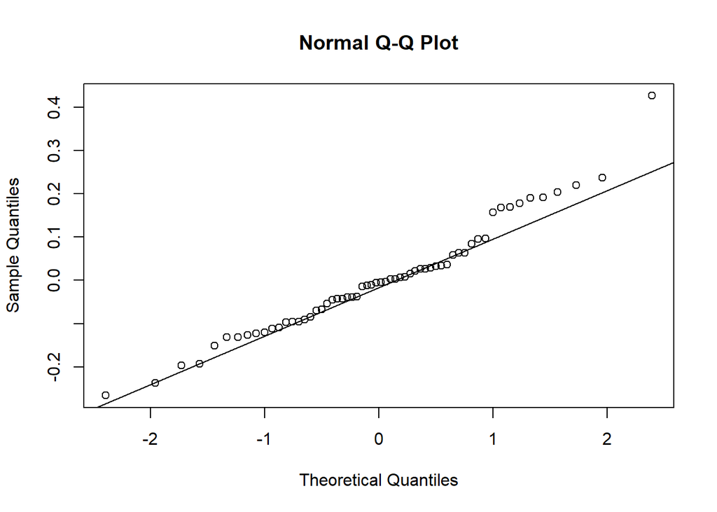

```r
random_intercept_UserId <- ranef(Speed_EP_InteractiveModel_nested_slopes)$UserId$`(Intercept)`
qqnorm(random_intercept_UserId)
qqline(random_intercept_UserId)
```

```r
shapiro.test(random_intercept_UserId)
```

```
##
##  Shapiro-Wilk normality test
##
## data:  random_intercept_UserId
## W = 0.96539, p-value = 0.08654
```

The qqplot varies slightly from the reference line, however, the Shapiro Test is not significant, and so we assume normality of UserId.

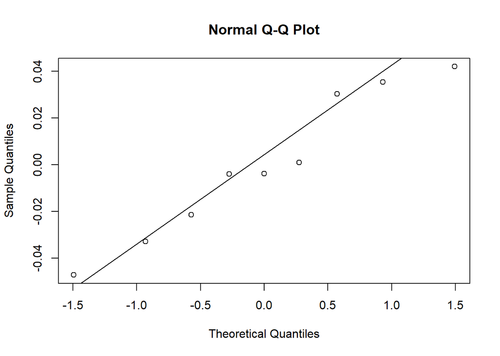

```r
random_intercept_StoryId <- ranef(Speed_EP_InteractiveModel_nested_slopes)$StoryId$`(Intercept)`
qqnorm(random_intercept_StoryId)
qqline(random_intercept_StoryId)
```

```r
shapiro.test(random_intercept_StoryId)
```

```
##
##  Shapiro-Wilk normality test
##
## data:  random_intercept_StoryId
## W = 0.9424, p-value = 0.6074
```

StoryId aligns much worse with the reference line, however, this is expected considering that StoryId only includes 9 different story groups. With the limited amount of information, achieving a visually normally distributed result is unlikely. Considering that the Shapiro Test is not significant, we can assume that StoryId random intercept is normally distributed.

#### 5. Normality of residuals

We first check normality of residuals by plotting model residuals and fitted values

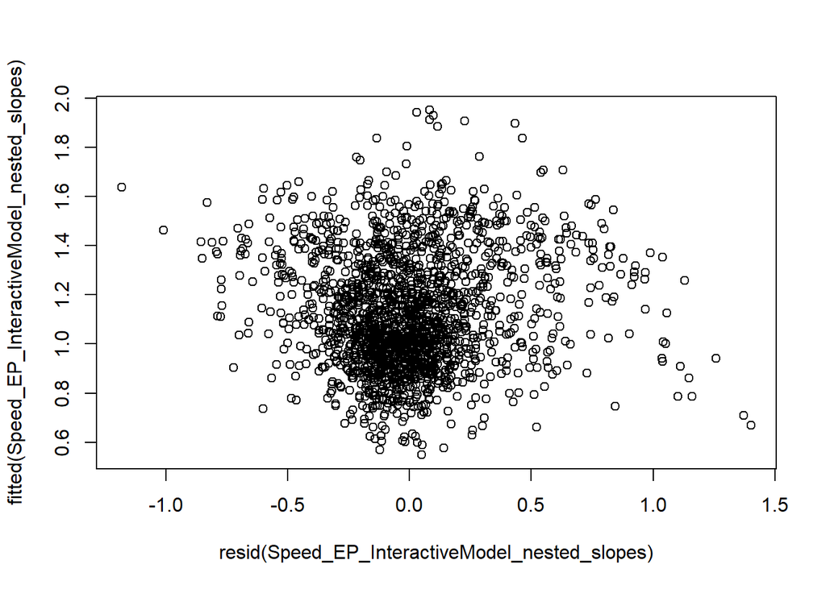

```r
plot(resid(Speed_EP_InteractiveModel_nested_slopes), fitted(Speed_EP_InteractiveModel_nested_slopes))
```

To further check non-normality, we use a qqplot:

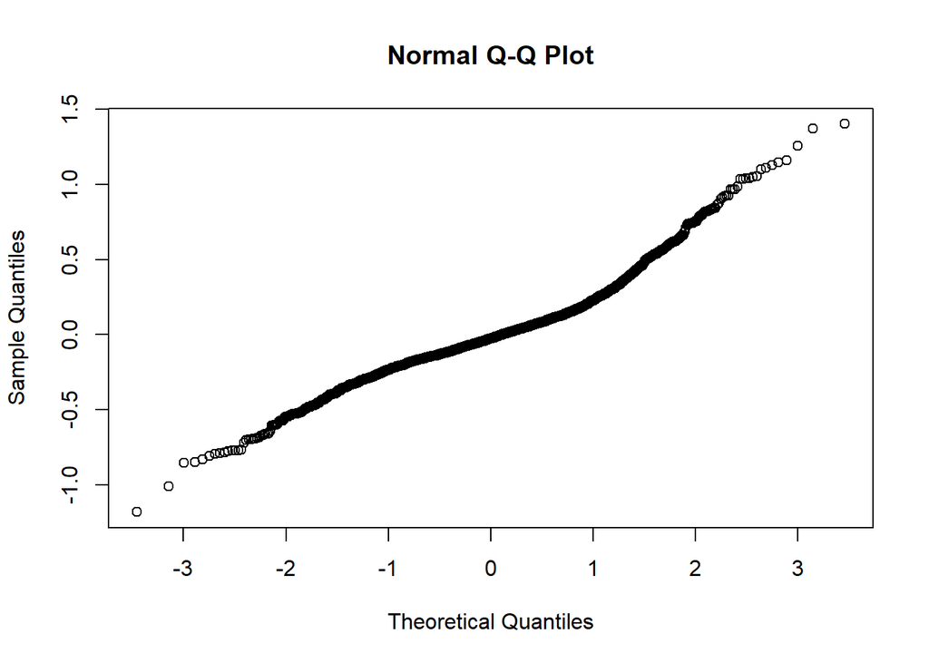

```r
qqnorm(residuals(Speed_EP_InteractiveModel_nested_slopes))
```

The qqplot shows slight variation from normality. However, the variation is not very extensive. Assess normality with a histogram of residuals:

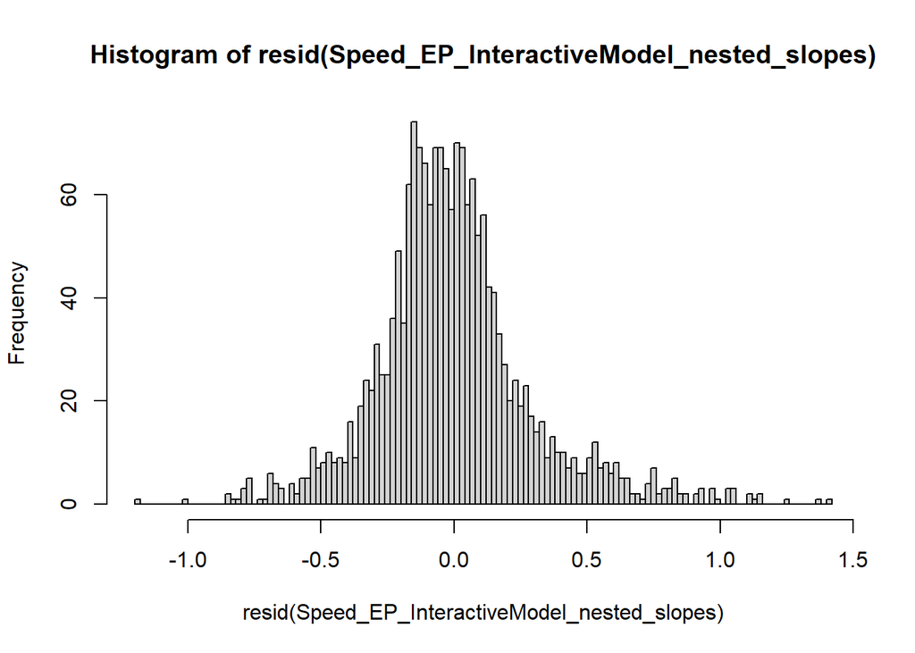

```r
hist(resid(Speed_EP_InteractiveModel_nested_slopes), breaks = 100)
```

The histogram shows a roughly normal distribution. We then inspect skewness and kurtosis in residuals:

```r
# 0 - normal, neg - left skew, pos - right skew
skewness(resid(Speed_EP_InteractiveModel_nested_slopes))
```

```
## [1] 0.7308844
```

```r
# 3 - normal, <3 playkurtic, >3 leptokurtic
kurtosis(resid(Speed_EP_InteractiveModel_nested_slopes))
```

```
## [1] 5.329314
```

The residuals are slightly skewed to the right, and the distribution is leptokurtic. Finally, we test normality with a Shapiro Wilkins test:

```r
# Shapiro Wilk Test
check_normality(Speed_EP_InteractiveModel_nested_slopes)
```

[output not shown]

As a result, we assume that the residuals are distributed normally enough for our purposes.

**Assumptions conclusion**

The model aligns with all assumptions.

### Interpret model

We then inspect model effects to interpret the results.

```r
summary(Speed_EP_InteractiveModel_nested_slopes)
```

```
## Linear mixed model fit by REML. t-tests use Satterthwaite's method [
## lmerModLmerTest]
## Formula: InteractiveStructure_EP_nested_slopes
##    Data: reading_speed_measure_data
## Control: lmerControl(optimizer = "bobyqa")
##
## REML criterion at convergence: 981.3
##
## Scaled residuals:
##     Min      1Q  Median      3Q     Max
## -3.9483 -0.5410 -0.0865  0.4123  4.6874
##
## Random effects:
##  Groups         Name                 Variance Std.Dev. Corr
##  UserId:StoryId (Intercept)          0.022912 0.15137
##                 DaysUntilDeadline.sc 0.003022 0.05497  0.92
##  StoryId        (Intercept)          0.002717 0.05213
##                 DaysUntilDeadline.sc 0.005423 0.07364  0.10
##  Residual                            0.089425 0.29904
## Number of obs: 1816, groups:  UserId:StoryId, 60; StoryId, 9
##
## Fixed effects:
##                                                   Estimate Std. Error
## (Intercept)                                      1.120e+00  3.036e-02
## WindowWidth.sc                                  -1.476e-02  2.218e-02
## DaysUntilDeadline.sc                             4.684e-02  3.217e-02
## Observation_lag1.sc                              6.676e-02  9.094e-03
## Observation_lag2.sc                              2.275e-02  9.240e-03
## ReadingSessionNumber.sc                          2.496e-02  1.950e-02
## TimeInReadingSession.sc                         -1.359e-02  1.628e-02
## PercentageLocation.sc                            5.622e-02  1.180e-02
## Observation_lag1.sc:Observation_lag2.sc         -1.282e-02  6.784e-03
## ReadingSessionNumber.sc:TimeInReadingSession.sc  2.547e-02  1.387e-02
## ReadingSessionNumber.sc:PercentageLocation.sc   -1.650e-02  8.697e-03
## TimeInReadingSession.sc:PercentageLocation.sc   -1.091e-02  9.551e-03
##                                                         df t value Pr(>|t|)
## (Intercept)                                      7.135e+00  36.878 2.08e-09 ***
## WindowWidth.sc                                   5.035e+01  -0.666   0.5086
## DaysUntilDeadline.sc                             6.219e+00   1.456   0.1939
## Observation_lag1.sc                              1.789e+03   7.341 3.20e-13 ***
```

[output cut: 21 more lines]

```
## RdSN.:TIRS.  0.018  0.062  0.060 -0.028 -0.038  0.275 -0.209  0.327  0.007
## RdngSN.:PL. -0.023 -0.048 -0.038  0.046  0.064 -0.217  0.261 -0.286  0.014
## TmInRS.:PL. -0.126  0.059  0.045  0.014  0.017  0.133 -0.486  0.271 -0.004
##             RSN.:T RSN.:P
## WndwWdth.sc
## DysUntlDdl.
## Obsrvtn_l1.
## Obsrvtn_l2.
## RdngSssnNm.
## TmInRdngSs.
## PrcntgLctn.
## Obs_1.:O_2.
## RdSN.:TIRS.
## RdngSN.:PL. -0.479
## TmInRS.:PL.  0.254 -0.047
```

In the event properties model, the following variables are significant predictors of reading rate: (1) Main effect of Observation_lag1 (Event<sub>k-1</sub>) (2) Main effect of Observation_lag2 (Event<sub>k-2</sub>) (3) Main effect of PercentageLocation

We first inspect the previous events (1-2), and then the remaining main effect (3).

#### Inspect impact of previous event

Observation_lag1 was a significant predictor of reading rate.

```r
speed_ep_previouslag1 <- effect_plot(
    Speed_EP_InteractiveModel_nested_slopes,
    pred = Observation_lag1.sc,
    plot.points = TRUE,
    point.alpha = .2,
    interval = TRUE
) +
    figure_theme_without_legend +
    labs(
        y = "Reading Speed as Proportion of Baseline Speed",
        x = addline_format("Event~k-1~:,Reading speed on previous page,(centered and scaled)")
    )
```

```
## Confidence intervals for merMod models is an experimental feature. The
## intervals reflect only the variance of the fixed effects, not the random
## effects.
```

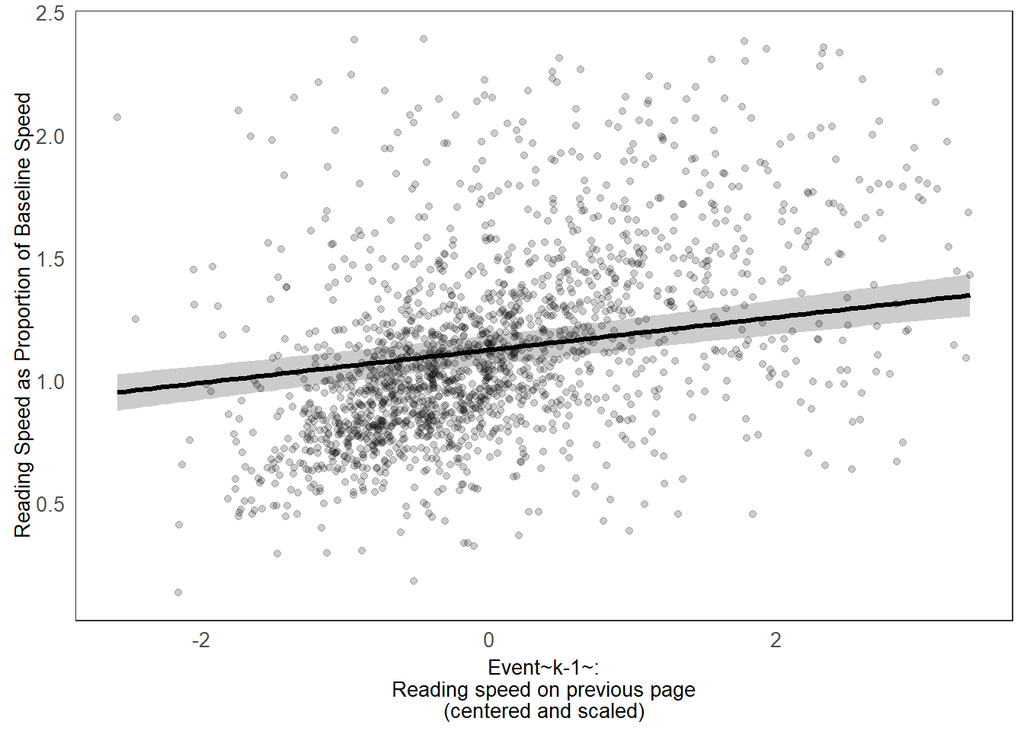

```r
speed_ep_previouslag1
```

There is a slight positive trend which indicates that a high reading speed on previous page-view (event k-1) predicts a high reading speed on the following page (event k).

Similarly, reading speed on the page before the previous (event k-2) was positively connected to reading speed (event k).

```r
speed_ep_previouslag2 <- effect_plot(
    Speed_EP_InteractiveModel_nested_slopes,
    pred = Observation_lag2.sc,
    plot.points = TRUE,
    point.alpha = .2,
    interval = TRUE
) +
    figure_theme_without_legend +
    labs(
        y = "Reading Speed as Proportion of Baseline Speed",
        x = addline_format("Event~k-2~:,Reading speed on the page before previous page,(centered and scaled)")
    )
```

```
## Confidence intervals for merMod models is an experimental feature. The
## intervals reflect only the variance of the fixed effects, not the random
## effects.
```

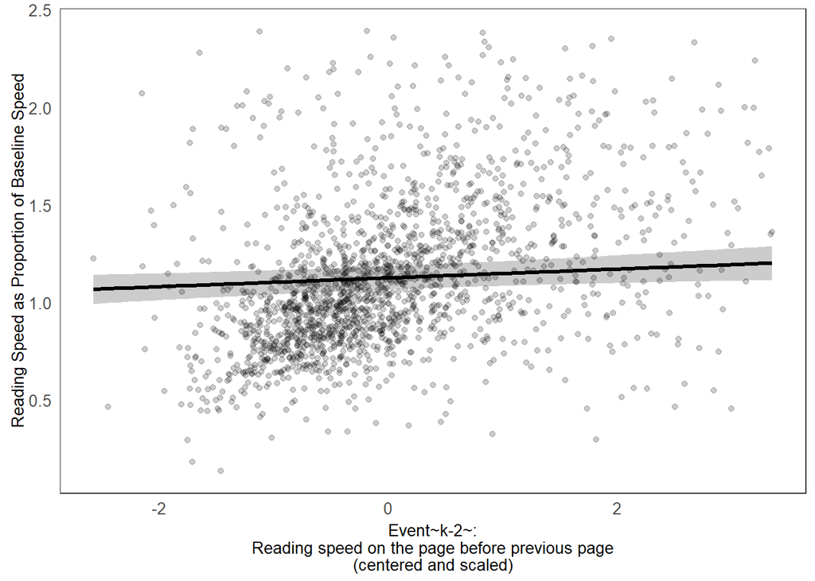

```r
speed_ep_previouslag2
```

This indicates that consecutive pages were often navigated at the same speed.

#### Impact of location in text

In addition to Observation_lag1 and Observation_lag2, reading speed was significantly predicted by PercentageLocation.

```r
speed_ep_location <- effect_plot(
    Speed_EP_InteractiveModel_nested_slopes,
    pred = PercentageLocation.sc,
    plot.points = TRUE,
    point.alpha = .2,
    interval = TRUE
) +
    figure_theme_without_legend +
    labs(
        y = "Reading Speed as Proportion of Baseline Speed",
        x = "Location in Text (%, centered and scaled)"
    )
```

```
## Confidence intervals for merMod models is an experimental feature. The
## intervals reflect only the variance of the fixed effects, not the random
## effects.
```

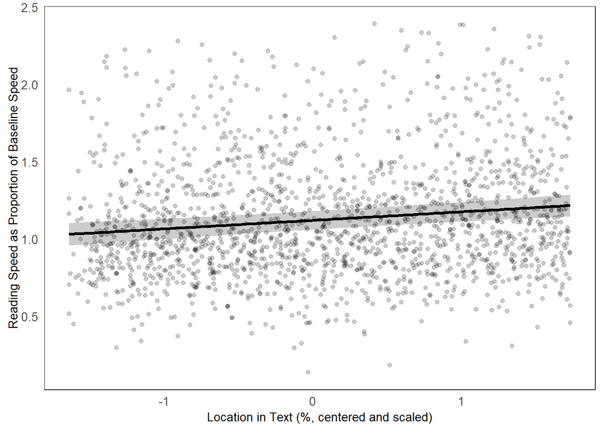

```r
speed_ep_location
```

Location and reading speed were positively correlated, indicating that participants had a tendency to increase their reading speed towards the end of the document.